# The reflection of the Syrian civil war on newspaper headlines between 2011-2023 : The Guardian example

2023-04-21

# Syrian Civil War from 2011-2023 in Guardian Headlines

## Introduction

### Research Question

- How the headlines related to Syrian Civil War has changed throughout the time (2011-2023)?

### Hypotheses

- While there was a softer discourse in the first couple of years of the war, the discourse changed after 2015 in the opposite direction.
- In particular, the unidentified “terrorist” attacks in Europe in recent years have been associated with the Syrian war and refugees.

##Data Analysis and Visualisations

### 2. Data Visualisation 1: Number of headlines by the dates (01-01-2011 to 15-04-2023)

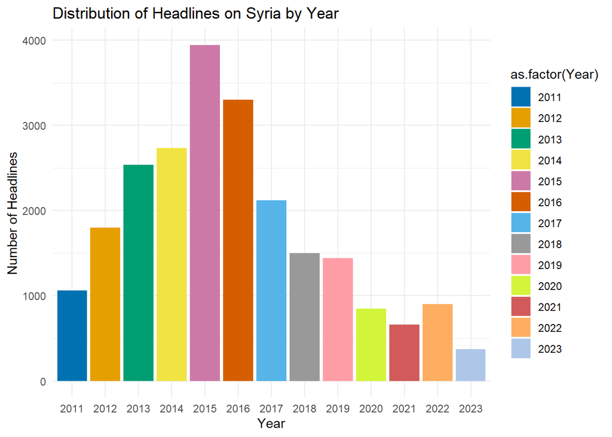

### 2. Data Visualisation 2. Keywords and Wordcloud

```r
# Import Syrian headlines and convert to corpus
syria_headlines_dataframe <- readRDS(file = "../Data files/syrian_headlines_dataframe.rds")


#Create new column containing only year and month for grouping later
headlines_month <- syria_headlines_dataframe %>%
  mutate(Month_Yr = format_ISO8601(datetime_vector, precision = "ym"))

#Identify important events with more than 200 headlines a month
top_headlines <- headlines_month %>%
  group_by(Month_Yr) %>%
  summarise(n=n()) %>%
  filter(n>200) %>%
  arrange(desc(n))

#Create vector containing months with more than 200 headlines
top_headline_dates <- top_headlines$Month_Yr
keywords_vector <- vector()

#Loop identifying the top 5 words for every month with more than 200 headlines
for (i in 1:length(top_headline_dates)){

current_date <- headlines_month %>%
  filter(Month_Yr==top_headline_dates[i])

current_corpus <- quanteda::corpus(current_date, text_field="headline_vector")

# Add more words to stop word dictionary
custom_dictionary <- stopwords("english")
custom_dictionary <- append(custom_dictionary,c("review", "video", "syria", "editorial"))

tokens_cleaned  <- tokens(current_corpus, remove_punct = TRUE, remove_numbers=TRUE, remove_symbols = TRUE, split_hyphens = TRUE,
                                remove_separators = TRUE, remove_url=TRUE)

no_stopwords <- tokens_remove(tokens_cleaned, custom_dictionary)

cleaned_dfm <- dfm(no_stopwords)
top_features <- topfeatures(cleaned_dfm , 5)
list_features <- list(names(top_features)) # so results display correctly
keywords_vector[i] <- list_features

}

#Display keywords in dataframe
keywords_by_date <- data.frame(top_headline_dates)
keywords_by_date$keywords  <- keywords_vector

# Customise keywords table
keywords_data_table <- as.data.table(keywords_by_date)
formatted_table <- formattable(keywords_data_table,
                               align=c("l","l"))
formatted_table
```

| top_headline_dates | keywords |
| --- | --- |
| 2015-11 | paris , isis , attacks , airstrikes, refugees |
| 2015-09 | refugees, refugee , crisis , says , syrian |
| 2013-09 | chemical, weapons , us , obama , un |
| 2014-09 | isis , us , strikes, iraq , air |
| 2015-12 | isis , airstrikes, war , labour , says |
| 2016-01 | isis , refugee, uk , says , us |
| 2015-10 | us , says , syrian , isis , refugee |
| 2016-03 | isis , brussels, attacks , syrian , eu |
| 2013-08 | chemical , intervention, attack , us , military |
| 2014-08 | isis , iraq , us , james, david |
| 2017-04 | trump , trump’s, us , attack , assad |
| 2016-02 | syrian, eu , says , uk , isis |
| 2019-10 | trump , us , briefing, isis , kurds |
| 2018-04 | us , trump , strikes , may , chemical |
| 2016-09 | us , syrian , trump , refugees, un |
| 2014-10 | isis , us , kobani , uk , british |
| 2014-06 | iraq , isis , us , crisis, iraqi |
| 2016-12 | aleppo, uk , says , russia, us |
| 2016-10 | aleppo, us , russia, trump , debate |
| 2017-01 | trump , ban , trump’s, travel , us |
| 2015-03 | isis , us , war , live , syrian |
| 2015-06 | isis , says , attack , tunisia, us |
| 2016-07 | us , isis , war , iraq , attack |
| 2015-07 | isis , uk , cameron, british, says |
| 2013-05 | syrian, us , crisis, rebels, says |
| 2016-11 | trump , us , isis , russia, aleppo |
| 2017-06 | trump , us , climate, paris , may |
| 2015-02 | isis , war , uk , mohammed, emwazi |
| 2016-04 | refugees, obama , us , isis , syrian |
| 2016-05 | isis , war , refugees, refugee , says |
| 2023-02 | earthquake, turkey , happened , ukraine , toll |
| 2014-01 | talks , syrian, peace , geneva, al |
| 2015-01 | isis , paris , attacks, charlie, saudi |
| 2013-06 | g8 , syrian , cameron, us , rebels |
| 2016-06 | jo , cox , says, eu , isis |
| 2014-11 | isis , us , uk , terror, peter |
| 2012-07 | syrian, assad , crisis, aleppo, regime |
| 2012-02 | syrian, homs , un , assad , arab |
| 2017-02 | trump , ban , travel , us , trump’s |

### 2. Data Visualisation 3. Word Cloud

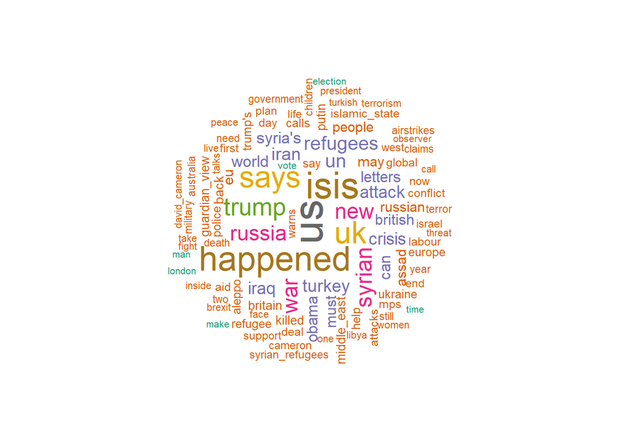

```r
###--- Create word cloud with key words from the corpus
current_corpus <- quanteda::corpus(syria_headlines_dataframe, text_field="headline_vector")

# Add more words to stop word dictionary
custom_dictionary <- stopwords("english")
custom_dictionary <- append(custom_dictionary,c("review", "video", "syria", "editorial"))

tokens_cleaned  <- tokens(current_corpus, remove_punct = TRUE, remove_numbers=TRUE, remove_symbols = TRUE, split_hyphens = TRUE,
                          remove_separators = TRUE, remove_url=TRUE)

# Remove stopwords
no_stopwords <- tokens_remove(tokens_cleaned, custom_dictionary)

# Identify 400 most common bigrams and combine then e.g. David Cameron, Al-Assad etc.
toks_ngram <- tokens_ngrams(no_stopwords, n = 2:2, concatenator = " ")
bigrams_dfm <- dfm(toks_ngram)
list <- as.list(topfeatures(bigrams_dfm , 400))
names <- names(list)

combined_tokens_list <- phrase(names)
tokens_combined <- tokens_compound(no_stopwords,combined_tokens_list, case_insensitive=TRUE)

# Create document frequency matrix and trim so that each term must be mentioned at least 3 times in total
cleaned_dfm <- dfm(tokens_combined) %>%
  dfm_trim(min_termfreq = 3)

# Plot wordcloud
set.seed(123) # ensure get same wordcloud every time
syria_wordcloud <- textplot_wordcloud(cleaned_dfm , max_words=100, rotation= 0.25, color = RColorBrewer::brewer.pal(8,"Dark2"))
```

```r
syria_wordcloud
```

[output not shown]

[output cut: 142 more lines]

[output not shown]

### 2. Data Visualisation 3. Interactive Headline Plot

```r
### --- Group headlines by month---
# Load vectors containing publication dates and headlines
dates_vector <- readRDS(file = "../Data files/syria_dates.rds")
headline_vector <- readRDS(file = "../Data files/syria_headlines.rds")
keywords <- readRDS(file="../Data files/keywords_by_date_dataframe.rds")

#Convert date in keywords dataframe and dates_vector to the same date format for joining later
keywords <- keywords %>%
  mutate(Date=lubridate::ym(top_headline_dates)) %>%
  mutate(Date=floor_date(as_date(Date), unit="month")) %>%
  select(-top_headline_dates)

# Convert character column to datetime
datetime_vector <- lubridate::ymd_hms(dates_vector)

#Convert vectors to dataframe
headlines_dates <- data.frame(datetime_vector,headline_vector)

#Count headlines per date
headline_month <- headlines_dates %>%
  mutate(Date=floor_date(as_date(datetime_vector), unit="month")) %>%
  count(Date)

# Join keywords and number of headline information for plotting later
dates_keywords <- left_join(headline_month,keywords)
#Plot headlines by date
headline_plot <- ggplot(data=dates_keywords, aes(x=Date, y=n))+
  geom_bar(stat="identity", fill="#445867")+
  ggtitle("Distribution of headlines on Syria")+
  ylab("Number of headlines")+
  scale_x_date(date_breaks = "1 year",date_labels="%Y")+
  theme_minimal()+
  theme(panel.grid.major = element_line(linetype="dashed"),
        panel.grid.minor = element_line(linetype="dashed"),
        axis.text.x=element_text(size=12))

### ---  Find keywords for the top 5 most frequent articles
top_5 <- dates_keywords %>%
  arrange(desc(n)) %>%
  head(5)

# 2015-11-01: ISIS attacks Paris and UK parliament debate airstrikes on Syria
# 2013-09-01: Chemical attacks on Ghouta

#Why are there so many headlines on 2019-10-01?
october_2019 <- dates_keywords %>%
  filter(Date=="2019-10-01")
# 2019-10-01: Trump thanks Kurds for role in killing ISIS leader Abu Bakr Al-Baghdadi

###--- Annotate bar plot with this information
str(dates_keywords)
```

[output not shown]

[output cut: 49 more lines]

[output not shown]

```r
#Format dates
dates_interest <- c("2019-10-01","2015-11-01","2013-09-01")
dates_interest_formatted <- as.Date(dates_interest, "%Y-%m-%d")

#Add vertical lines
headline_plot_annotated <- headline_plot+
  geom_vline(xintercept = dates_interest_formatted, linetype="dashed", linewidth=0.5, alpha=0.8)

#Add text
text2013 <- "Chemical attacks on Ghouta"
text2015 <- "Terrorists attack Paris and UK parliament \n debate airstrikes on Syria"
text2019 <- "Trump thanks Kurds for role in killing \n ISIS leader Abu Bakr Al-Baghdadi"

headline_plot_text_1 <- headline_plot_annotated+
  annotate("text", x=dates_interest_formatted[1], y=350,label=text2019,
           col="black", size=4)

headline_plot_text_2 <- headline_plot_text_1+
  annotate("text", x=as.Date("2016-1-01", "%Y-%m-%d"), y=700,label=text2015,hjust=0,
           col="black", size=4)

headline_plot_text_3 <- headline_plot_text_2+
  annotate("text", x=dates_interest_formatted[3], y=600,label=text2013,
           col="black", size=4)

### --- Add interactivity to bar chart plot
headlines_plotly <- ggplotly(headline_plot_text_3) %>%  # convert ggplot to interactive plotly chart
  add_trace(Date=dates_keywords$Date,
            Articles=n,
            hovertemplate = paste('<i>Date</i>: <b>%{Date}</b>','<i>Article</i>: <b>%{Articles}</b>'))
```

[output not shown]

## Results & Conclusion

In this exercise, we analysed the changes in the headlines in the Guardian newspaper since the beginning of the Syrian civil war (2011). Out of a total of 23617 news headlines, we noticed 39 dates that we came across most frequently in news headlines about Syria. On the top of the list, in which Syria was mentioned the most, November 2015. Surprisingly, the date was related to the Paris attacks (https://en.wikipedia.org/wiki/November_2015_Paris_attacks). The assaults, according to French President François Hollande, were an act of war by Islamic State and they were planned in Syria and organised by a terrorist cell in Belgium. The attackers were born in France and Belgium but also fought in Syria and they returned to France through flow of migrants and refugees from Syria. We could also argue from today that after these attacks, the policies and political discourse towards Syrian refugees and migrants have radically changed.